# Reproducible research project 1 rework

## Step 8. Creating factor variable on the weekday… using for loop to create factor variable for each row

```r
activitynomissing$date <- ymd(activitynomissing$date)

activitynomissing$day <- weekdays(activitynomissing$date)

for (i in 1:nrow(activitynomissing))
{
    if(activitynomissing[i,]$day %in% c("Saturday","Sunday"))
    {
        activitynomissing[i,]$day="weekend"
    }
    else
    {
        activitynomissing[i,]$day="weekday"
    }
}
```

##making a panel plot containing a time series plot of the 5-minute interval (x-axis) and ##the average number of steps taken, averaged across all weekday days or weekend days (y-axis).

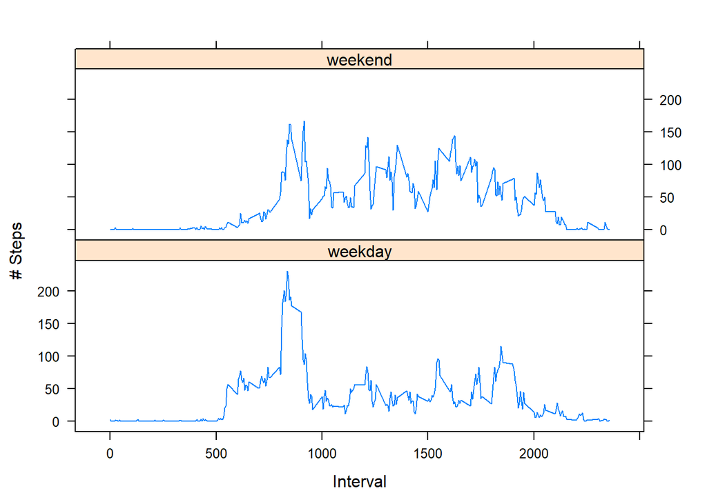

```r
stepbydaytype <- aggregate(activitynomissing$steps~activitynomissing$interval + activitynomissing$day,activitynomissing,mean)

names(stepbydaytype) <- c("interval", "day", "steps")

xyplot(steps~interval|day,stepbydaytype,type="l",layout=c(1,2),xlab="Interval",ylab="# Steps")
```